# Lab 03 - Graphics

#### [Coding in R for Policy Analytics](https://ds4ps.org/cpp-526-spr-2020/)

*This lab introduces core plotting functions in order to create customized graphics in R.*

You can create a new R Markdown file, or download the **LAB-03 RMD template**:

# Visualizing Gapminder Data

**[Gapminder](https://www.gapminder.org/)** is a self-described “independent educational non-profit fighting global misconceptions” about anything from plastic in the ocean to farmers income and a host of other compelling and robust global data sources.

*Gapminder’s* life expectancy data rose to prominence following particularly legendary examples of data storytelling by Swedish physician, academic, and *Gapminder* Co-Founder and Chairman **[Hans Rosling](https://en.wikipedia.org/wiki/Hans_Rosling)**. Watch one of his famous TED Talks by clicking on the image below to familiarize yourself with *Gapminder.*

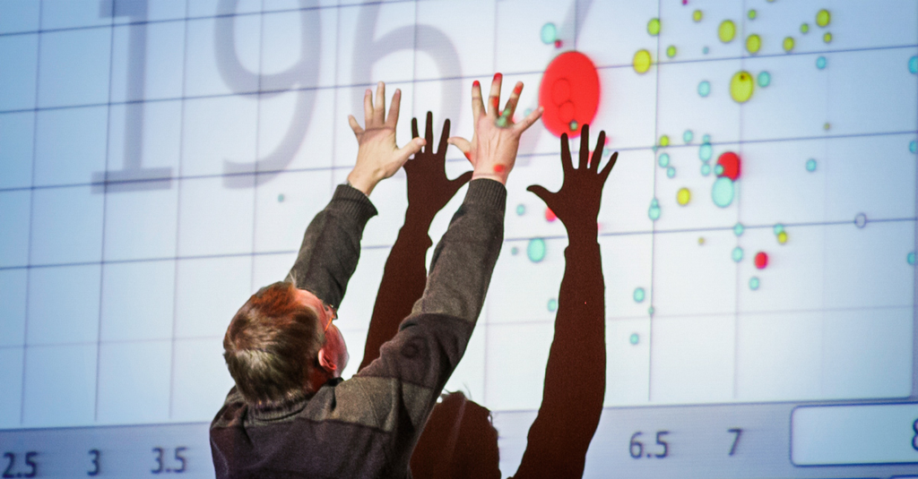

For this lab, you will replicate novel visualizations using *Gapminder* data on average life expectancy by country over time.

# Visuals to Replicate

You must replicate the following visual *as closely as possible*. Reproduced and submitted data visualizations which fail to replicate less than 80% of the visual elements in these images is unacceptable.

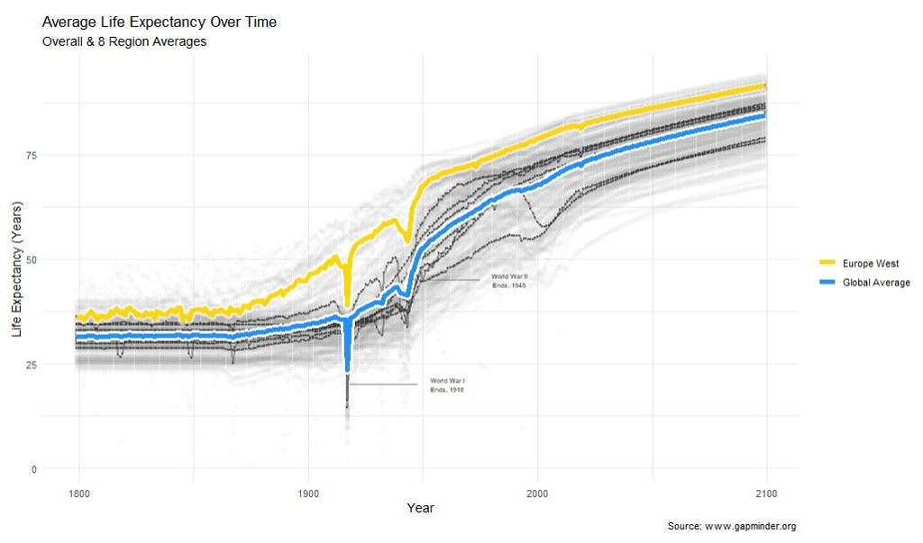

# Graphics Packages

In order to replicate the provided graphics, you may use either the base R `graphics` package or package `ggplot2`. Learners who use `ggplot2` may convert their graphic into an interactive visualization using package `plotly` function `ggplotly()`.

# Functions

### Package “graphics”

If using package `graphics`, you must likely use the following functions:

```r
plot()
plot.new()
plot.window()
points()
gray()
axis()
title()
text()
mtext()
segments()
abline()
```

### Package “ggplot2”

If using package `ggplot2`, you will likely use the following functions:

```r
ggplot()
aes()
geom_point()
geom_jitter()
geom_segment()
geom_line()
labs()
scale_x_continuous()
scale_y_continuous()
theme_minimal()
annotate()
```

Consider passing your `ggplot2` graphic to package `plotly` function `ggplotly()` to quickly convert it to an interactive graphic!

# Data

Your data are sourced directly from **[Gapminder](https://www.gapminder.org/)**. While R does have a regularly updated `gapminder` **[package](https://cran.r-project.org/web/packages/gapminder/index.html)**, it is significantly less rich in only providing data every five years.

*Gapminder* countries are categorized into four, six, and eight global regions. In this example, you will use the eight-region classification for optimal granularity.

### Import

Run the following commands to import region group and life expectancy data. The data required for the visualization is largely preprocessed for your convenience below.

```r
library(tidyverse)

url <- paste0("https://raw.githubusercontent.com/cssearcy/AYS-R-Co",
              "ding-SPR-2020/master/LABS/gapminder_group_data.csv")

regions <- read_csv(file = url) %>%         # Import country region data
  select(Country = name,
         Region = eight_regions) %>%
  mutate(Region = str_replace_all(string = Region,
                                  pattern = "_",
                                  replacement = " "),
         Region = str_to_title(Region))

url <- paste0("https://raw.githubusercontent.com/cssearcy/AYS-R-Co",
              "ding-SPR-2020/master/LABS/gapminder_life_exp.csv")

life_exp <- read_csv(file = url) %>%        # Import, merge life expectancy data
  pivot_longer(cols = -country) %>%
  rename("Country" = country,
         "Year" = name,
         "Lifespan" = value) %>%
  left_join(regions) %>%
  mutate(Year = as.numeric(Year)) %>%
  select(Region, Country, Year, Lifespan) %>%
  arrange(Region, Country, Year, Lifespan)

region_avgs <- life_exp %>%
  group_by(Year, Region) %>%
  summarize(Average = mean(Lifespan,
                           na.rm = TRUE))

year_avg <- life_exp %>%
  group_by(Year) %>%
  summarize(Average = mean(Lifespan,
                           na.rm = TRUE))
```

### Preview

The following shows the first 10 observations in the life expectancy data: `life_exp`.

```r
head(life_exp, 10)
```

| Region | Country | Year | Lifespan |
| --- | --- | --- | --- |
| Africa North | Algeria | 1799 | 28.8 |
| Africa North | Algeria | 1800 | 28.8 |
| Africa North | Algeria | 1801 | 28.8 |
| Africa North | Algeria | 1802 | 28.8 |
| Africa North | Algeria | 1803 | 28.8 |
| Africa North | Algeria | 1804 | 28.8 |
| Africa North | Algeria | 1805 | 28.8 |
| Africa North | Algeria | 1806 | 28.8 |
| Africa North | Algeria | 1807 | 28.8 |
| Africa North | Algeria | 1808 | 28.8 |

The following shows the first 10 observations in the regional average data: `region_avgs`.

```r
head(region_avgs, 10)
```

| Year | Region | Average |
| --- | --- | --- |
| 1799 | Africa North | 31.11667 |
| 1799 | Africa Sub Saharan | 30.41277 |
| 1799 | America North | 31.10000 |
| 1799 | America South | 32.95000 |
| 1799 | Asia West | 28.73704 |
| 1799 | East Asia Pacific | 29.79286 |
| 1799 | Europe East | 34.48696 |
| 1799 | Europe West | 36.17000 |
| 1799 | NA | 34.20000 |
| 1800 | Africa North | 31.11667 |

```r
head(year_avg, 10)
```

| Year | Average |
| --- | --- |
| 1799 | 31.50376 |
| 1800 | 31.46344 |
| 1801 | 31.48011 |
| 1802 | 31.38548 |
| 1803 | 31.46075 |
| 1804 | 31.58656 |
| 1805 | 31.64409 |
| 1806 | 31.59839 |
| 1807 | 31.38548 |
| 1808 | 31.31344 |

# Getting Started

The following code will help you get started in either `graphics` or `ggplot2`.

### Package “ggplot2”

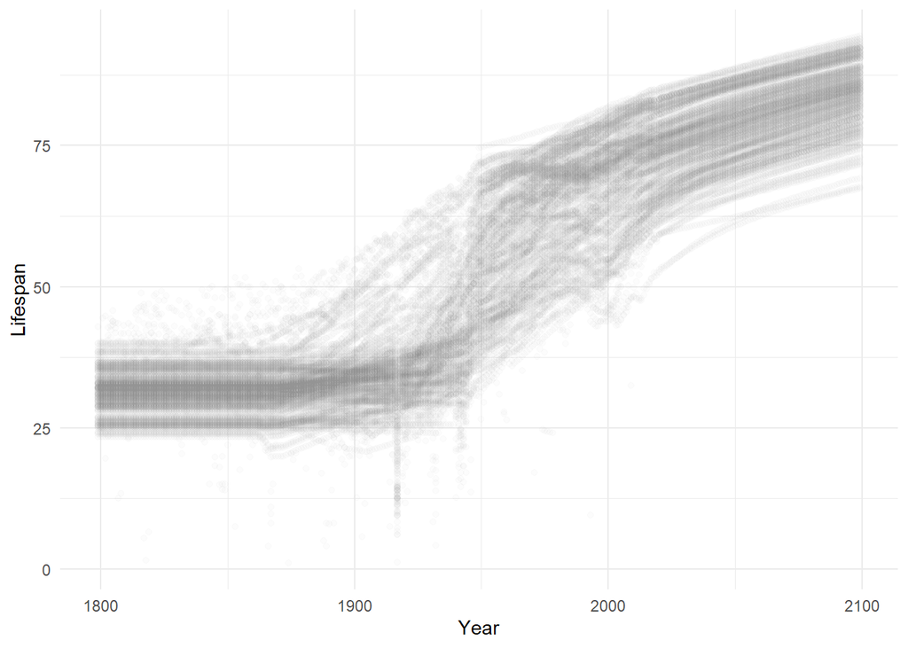

```r
ggplot(life_exp, aes(x = Year,
                     y = Lifespan)) +
  geom_point(alpha = 0.025,
             color = "grey50") +
  theme_minimal()
```

### Package “graphics”

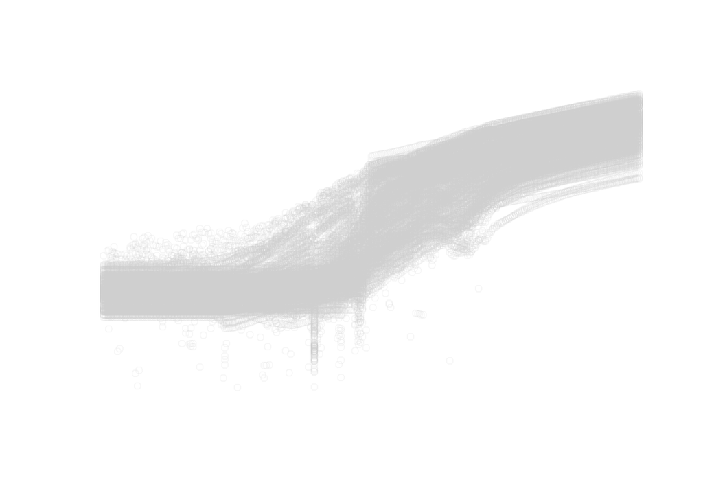

```r
plot.new()

plot.window(xlim = c(min(life_exp$Year, na.rm = TRUE),
                     max(life_exp$Year, na.rm = TRUE)),
            ylim = c(min(life_exp$Lifespan, na.rm = TRUE),
                     max(life_exp$Lifespan, na.rm = TRUE))) # Specify dimensions

points(life_exp$Year,
       life_exp$Lifespan,
       col = alpha(colour = "grey80",
                   alpha = 0.15))
```

# Hints

You can often rely on internal documentation as well as the web.

### Internal Documentation

If you need help looking up arguments remember these two helpful functions:

- `help()`
- `args()`

For example:

```r
args(abline)
help(mtext)
```

### External Message Boards

This lab assignment will push you to explore the nuances of these functions and their arguments. Don’t hesitate to use the web to overcome challenging function modifications.

1. Include the language, i.e. “r”
2. Include the function name, e.g. `text()`
3. Concisely describe your intent, e.g. “allow text overflow”

# How to Submit

Use the following instructions to submit your assignment, which may vary depending on your course’s platform.

### Knitting to HTML

When you have completed your assignment, click the “Knit” button to render your `.RMD` file into a `.HTML` report.

### Special Instructions

Perform the following depending on your course’s platform:

- **Canvas:** Upload both your `.RMD` and `.HTML` files to the appropriate link
- **Blackboard or iCollege:** Compress your `.RMD` and `.HTML` files in a `.ZIP` file and upload to the appropriate link

`.HTML` files are preferred but not allowed by all platforms.

### Before You Submit

Remember to ensure the following before submitting your assignment.

1. Name your files using this format: **Lab-##-LastName.rmd** and **Lab-##-LastName.html**
2. Show both the solution for your code and write out your answers in the body text
3. Do not show excessive output; truncate your output, e.g. with function `head()`
4. Follow appropriate styling conventions, e.g. spaces after commas, etc.
5. Above all, ensure that your conventions are consistent

See [Google’s R Style Guide](https://google.github.io/styleguide/Rguide.xml) for examples of common conventions.

### Common Knitting Issues

`.RMD` files are knit into `.HTML` and other formats procedural, or line-by-line.

- An error in code when knitting will halt the process; error messages will tell you the specific line with the error
- Certain functions like `install.packages()` or `setwd()` are bound to cause errors in knitting
- Altering a dataset or variable in one chunk will affect their use in all later chunks
- If an object is “not found”, make sure it was created or loaded with `library()` in a previous chunk

**If All Else Fails:** If you cannot determine and fix the errors in a code chunk that’s preventing you from knitting your document, add `eval = FALSE` inside the brackets of `{r}` at the beginning of a chunk to ensure that R does not attempt to evaluate it, that is: `{r eval = FALSE}`. This will prevent an erroneous chunk of code from halting the knitting process.